# 2.2.1 HT1080 LOY vs sgCTRL — RNA-seq base analysis

# Overview

HT1080 **LOY vs sgCTRL** RNA-seq analysis (AUG 2025 batch — reprocessed under the standardized STAR two-pass + featureCounts v2.1.1 / GENCODE v49 pipeline). HT1080 is a fibrosarcoma line carrying activating **NRAS Q61K** with wild-type p53. LOY was generated by transient nucleofection of a Y-chromosome-targeting sgRNA; sgCTRL is the matched non-targeting sgRNA control; PARENTAL is the unmodified parental population. Three replicates per group were grown in parallel and sequenced in the same batch.

Every figure is saved to `figures_LOY_sgCTRL/` as both PNG (for iterative review) and PDF (for publication).

[output not shown]

# 1. Setup

## 1.1 Load Packages

## 1.2 Paths, Parameters, and PNG-First Figure Helper

## 1.3 Auto-generate Sample Metadata from Filenames

HT1080 Sample Summary

| treatment | n | replicates | y_status |
| --- | --- | --- | --- |
| CTRL | 3 | 1, 2, 3 | Y+ |
| LOY | 3 | 1, 2, 3 | Y- |
| PARENTAL | 3 | 1, 2, 3 | Y+ |

## 1.4 Load Count Data

```
## Loading 9 HT1080 count files from
##    A:/Dropbox/LOY_paralogs/projects/RNAseq/counts/AUG_2025_HT1080_LOY
```

```
## Loaded 78899 genes across 9 samples
```

# 2. QC: DGEList, Filter, TMM

## 2.1 Build DGEList (2-level treatment factor)

```
## Removing 54543 genes without full annotation
```

```
## Genes remaining: 24356
```

## 2.2 Filter Low-Expressed Genes

```
## Before filtering: 24356
```

```
## After filtering:  14466
```

## 2.3 TMM Normalization

Library sizes and normalization factors

|  | treatment | passage | lib.size | norm.factors | lib.size_M | effective_lib |
| --- | --- | --- | --- | --- | --- | --- |
| HT1080-CTRL-1 | CTRL | 1 | 60544378 | 0.9983829 | 60.5 | 60.4 |
| HT1080-CTRL-2 | CTRL | 2 | 59208605 | 1.0309670 | 59.2 | 61.0 |
| HT1080-CTRL-3 | CTRL | 3 | 59959496 | 1.0357508 | 60.0 | 62.1 |
| HT1080-LOY-1 | LOY | 1 | 55784125 | 1.0058688 | 55.8 | 56.1 |
| HT1080-LOY-2 | LOY | 2 | 55858188 | 0.9876616 | 55.9 | 55.2 |
| HT1080-LOY-3 | LOY | 3 | 59838734 | 1.0241758 | 59.8 | 61.3 |
| HT1080-PARENTAL-1 | PARENTAL | 1 | 57638175 | 0.9123412 | 57.6 | 52.6 |
| HT1080-PARENTAL-2 | PARENTAL | 2 | 59259541 | 1.0148560 | 59.3 | 60.1 |
| HT1080-PARENTAL-3 | PARENTAL | 3 | 55252206 | 0.9956740 | 55.3 | 55.0 |

## 2.4 PCA

### All samples — PC1 vs PC2

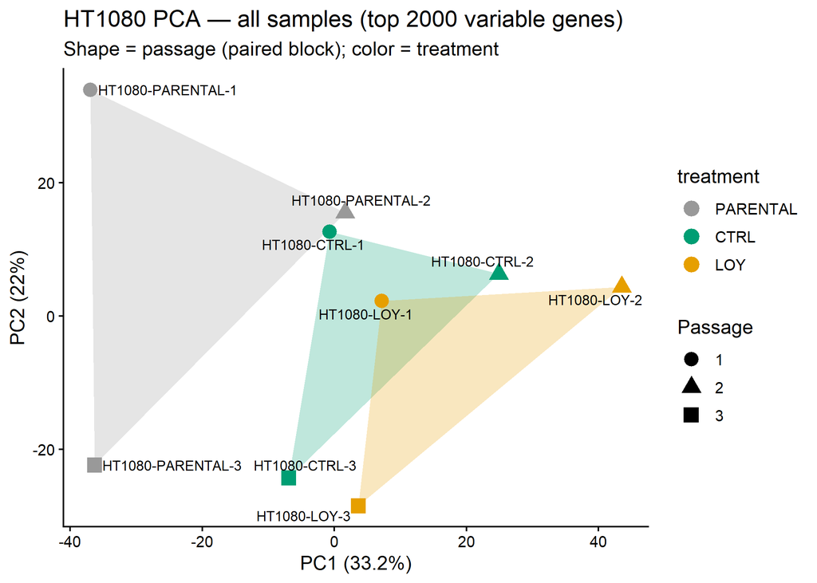

```
## Saved: pca_pc1_pc2.(png|pdf)  [7x5 in]
```

### All samples — PC1 vs PC3

PC2 is often dominated by passage drift. PC3 may resolve treatment biology more cleanly once passage variance is partitioned out.

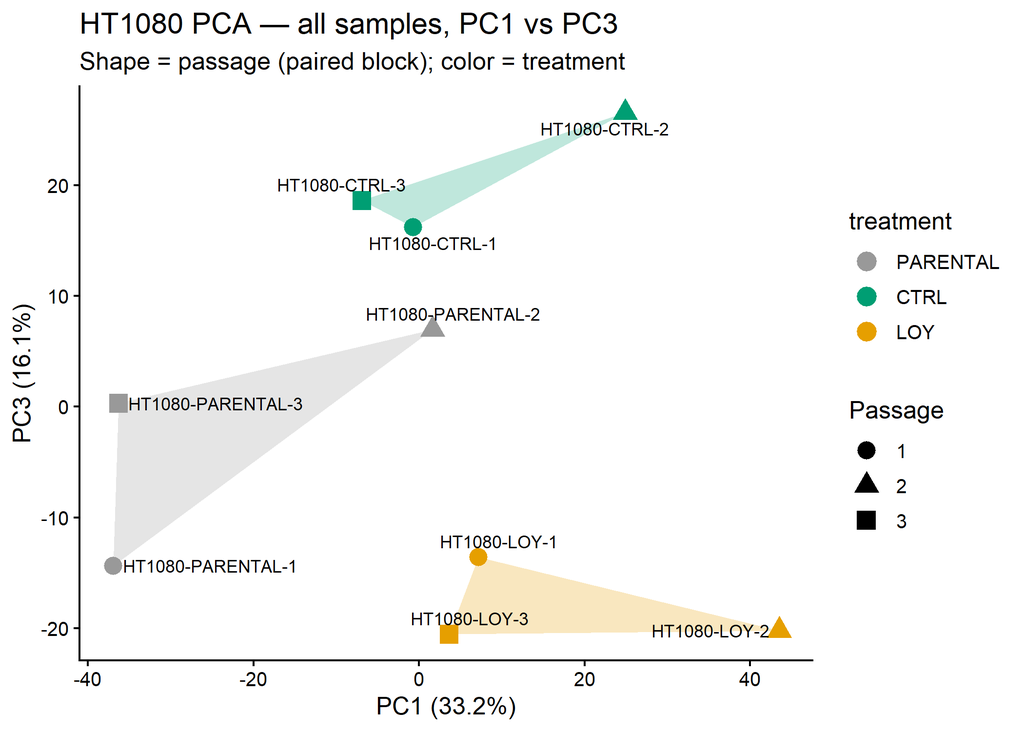

```
## Saved: pca_pc1_pc3.(png|pdf)  [7x5 in]
```

### LOY vs sgCTRL only — PC1 vs PC2

PARENTAL samples dropped; `prcomp` re-run on the 6-sample subset so PC axes reflect only LOY-vs-sgCTRL biology + passage drift.

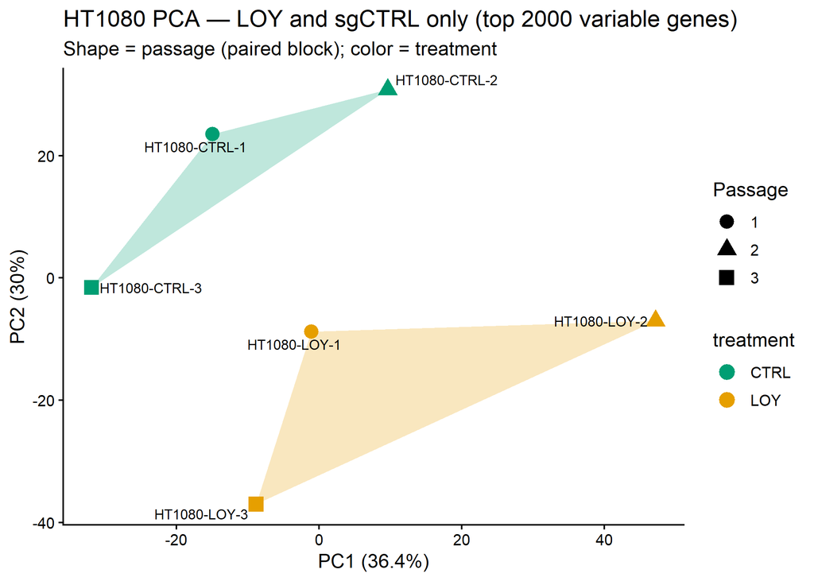

```
## Saved: pca_loy_ctrl_pc1_pc2.(png|pdf)  [7x5 in]
```

### LOY vs sgCTRL only — PC1 vs PC3

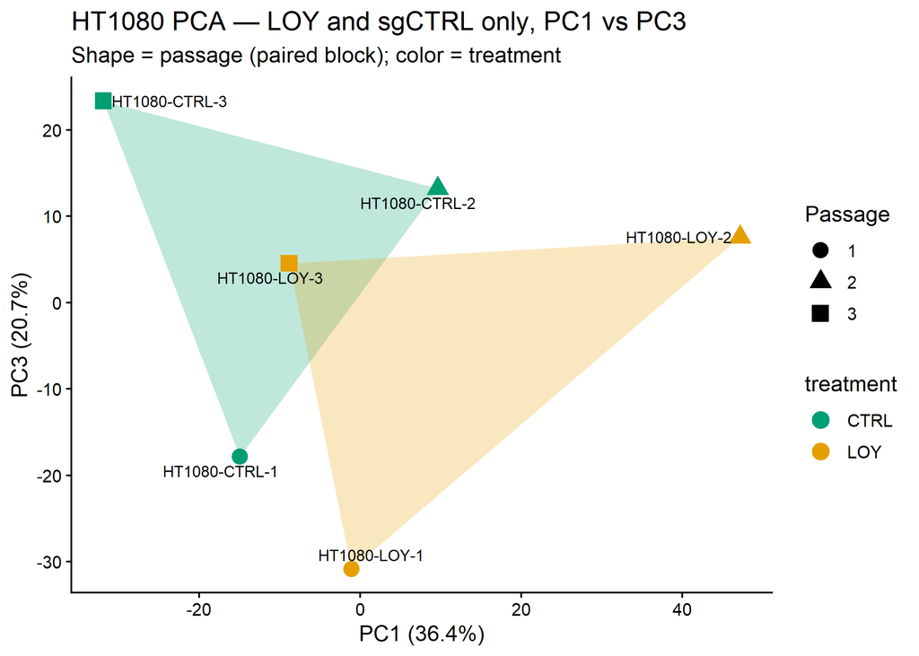

```
## Saved: pca_loy_ctrl_pc1_pc3.(png|pdf)  [7x5 in]
```

## 2.5 Sample distance heatmap

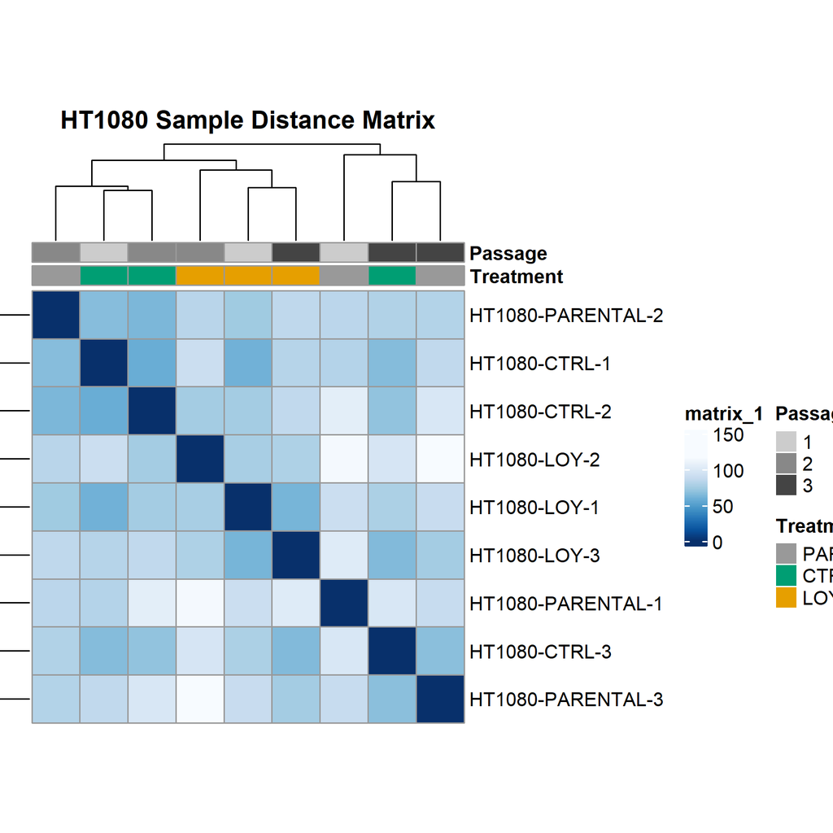

# 3. Y Chromosome Expression

Sanity check: LOY samples should show markedly lower expression of Y-chromosome protein-coding genes than sgCTRL.

```
## Y chromosome genes in data: 9 / 53
```

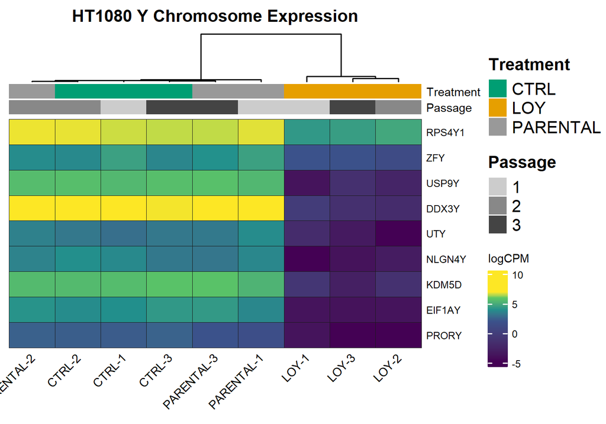

## 3.2 Per-sample summary + key paralogs

A two-panel complement to the heatmap. **Top**: total Y-chromosome expression per sample — a single quantitative bar per sample that should drop sharply in the three LOY columns. **Bottom**: per-gene boxplots for the six paralogs central to the mechanistic model — *KDM5D* and *UTY* (H3K4me3 / H3K27me3 demethylase loss-of-function), plus *RPS4Y1*, *EIF1AY*, *DDX3Y*, and *USP9Y* (broadly expressed Y-linked housekeepers that confirm the loss is genome-wide across the chromosome, not just at the chromatin-regulator locus).

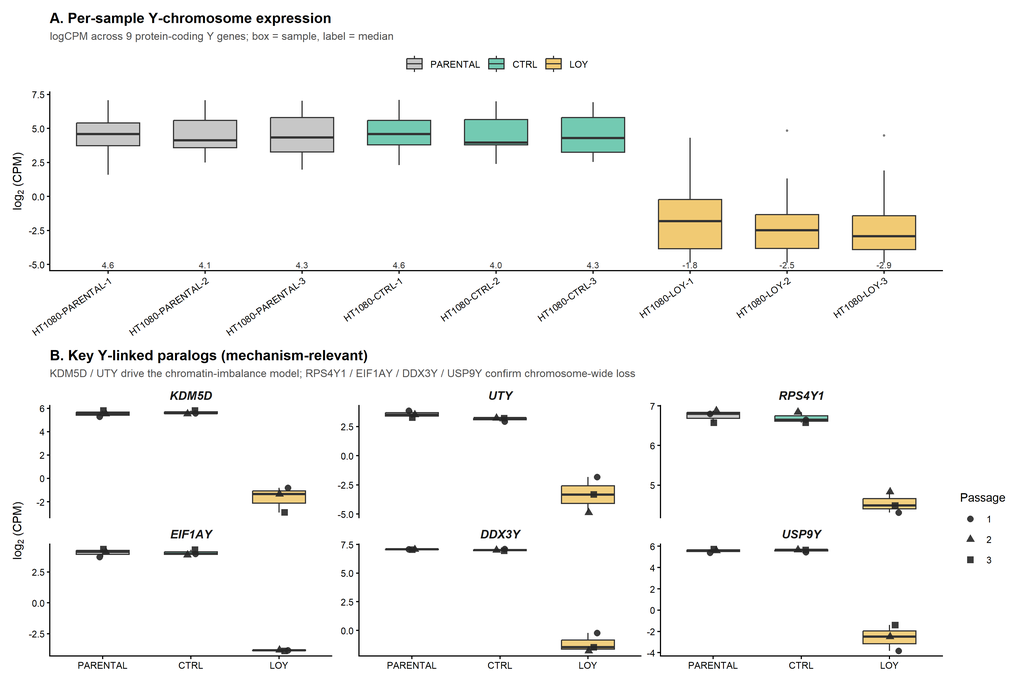

```
## Saved: y_chromosome_summary_and_paralogs.(png|pdf)  [12x8 in]
```

# 4. Differential Expression: LOY vs sgCTRL

Two designs are fit on `dge_lc` (Y-chromosome genes removed, TMM recalculated): **paired** (treatment + passage) is the recommended primary analysis; **unpaired** is shown for reference. Downstream GSEA in section 5+ uses the paired results.

```
## Removing 9 Y chromosome genes
```

```
## DE working set: 6 samples (CTRL/LOY)
```

## Paired (treatment + passage)

Design: `~ 0 + treatment + passage`. Passage covariate absorbs per-passage drift before the `LOY - CTRL` contrast.

```
## Design columns: CTRL, LOY, passage2, passage3
```

```
##
## Paired DE — LOY vs sgCTRL: 14457 genes tested
```

```
##   FDR < 0.05:              1139
```

```
##   FDR < 0.05 & |logFC| > 0.75:  505 (up: 202, down: 303)
```

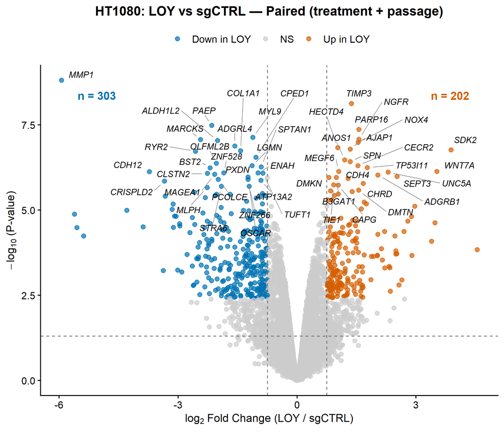

```
## Saved: volcano_LOY_v_sgCTRL_paired.(png|pdf)  [7x6 in]
```

## Unpaired (treatment only)

Design: `~ 0 + treatment`. Passage drift not modeled — reference for what the statistics look like without the covariate.

```
## Design columns: CTRL, LOY
```

```
##
## Unpaired DE — LOY vs sgCTRL: 14457 genes tested
```

```
##   FDR < 0.05:              15
```

```
##   FDR < 0.05 & |logFC| > 0.75:  15 (up: 3, down: 12)
```

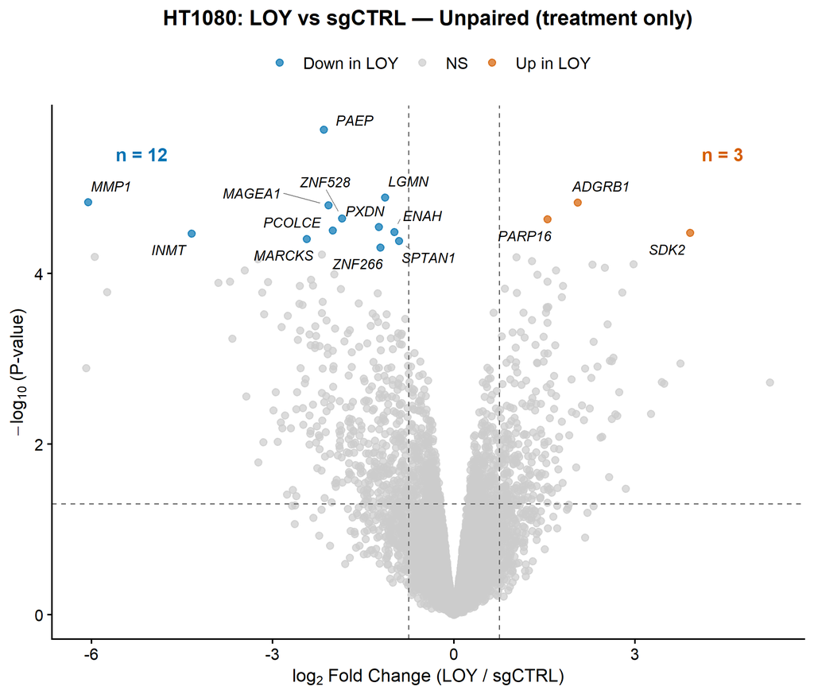

```
## Saved: volcano_LOY_v_sgCTRL_unpaired.(png|pdf)  [7x6 in]
```

# 5. GSEA (Basic Collections)

## 5.1 Setup: ranks + basic pathways

```
## Loading basic MSigDB collections...
```

```
##   hallmark: 50 gene sets
##   reactome: 1787 gene sets
##   kegg: 186 gene sets
##   go_bp: 7583 gene sets
```

## 5.2 Build ranks (RPS/RPL filtered)

```
## Ranked gene list: 14454 genes
```

```
## Removing 91 ribosomal protein genes (RPS/RPL)
```

```
## After RPS/RPL filter: 14363 genes
```

## 5.3 Run fgsea and save

```
## Running fgsea (basic collections) for LOY vs sgCTRL...
```

```
##   Running hallmark (50 gene sets)...
##   Running reactome (1787 gene sets)...
##   Running kegg (186 gene sets)...
##   Running go_bp (7583 gene sets)...
```

## 5.4 Summary

LOY vs sgCTRL — Significant pathways by collection

| collection | total | sig_up | sig_down |
| --- | --- | --- | --- |
| go_bp | 3574 | 55 | 91 |
| hallmark | 50 | 7 | 14 |
| kegg | 162 | 0 | 0 |
| reactome | 985 | 40 | 37 |

## 5.5 Publication dotplot

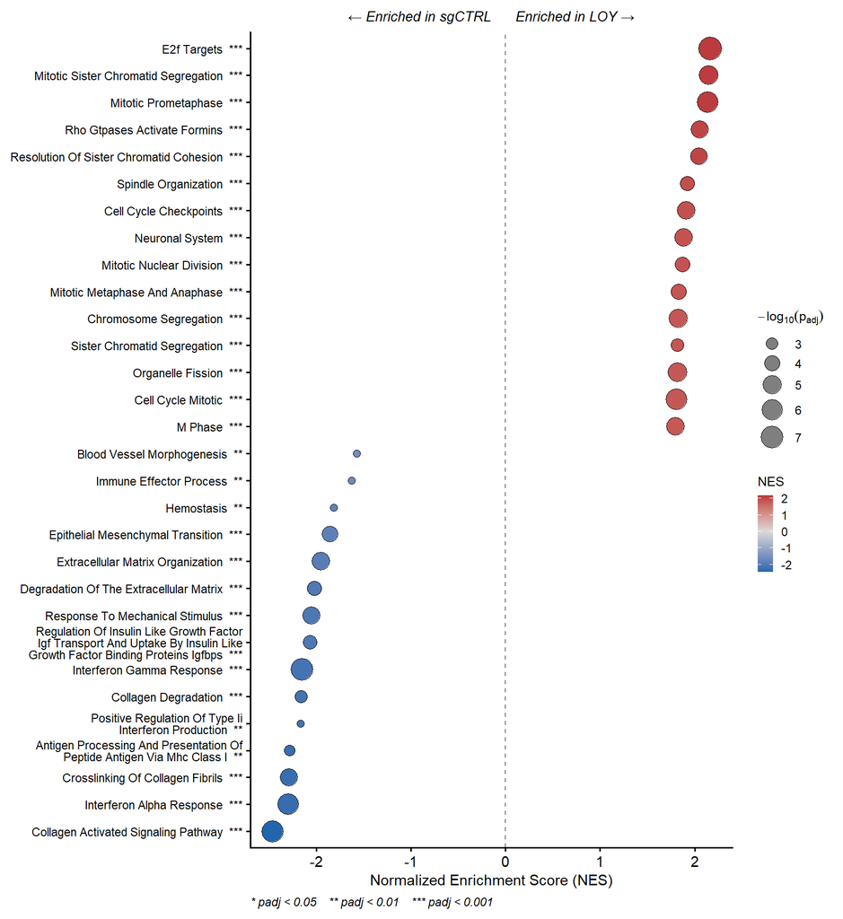

```
## Saved: gsea_dotplot_basic.(png|pdf)  [5.5x6 in]
```

## 5.6 Top Hallmark enrichment plots

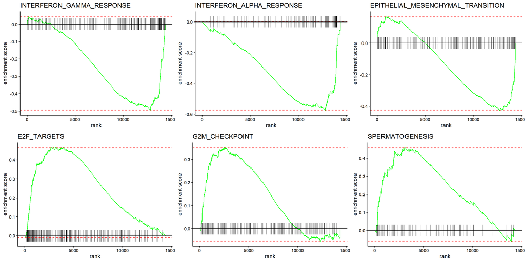

```
## Saved: gsea_enrichment_top_hallmark.(png|pdf)  [12x6 in]
```

# 6. GSEA (Expanded: +CGP, +CP subsets)

## 6.1 Load expanded collections

```
## Loading expanded MSigDB collections...
```

```
##   hallmark: 50 gene sets
##   c2_all: 7561 gene sets
##   cgp: 3538 gene sets
##   cp: 19 gene sets
##   cp_biocarta: 292 gene sets
##   cp_kegg_med: 658 gene sets
##   cp_pid: 196 gene sets
##   cp_reactome: 1787 gene sets
##   cp_wikipath: 885 gene sets
##   cp_kegg_leg: 186 gene sets
```

## 6.2 Run expanded fgsea

```
## Running fgsea (expanded) for LOY vs sgCTRL...
```

```
##   Running hallmark (50 gene sets)...
##   Running c2_all (7561 gene sets)...
##   Running cgp (3538 gene sets)...
##   Running cp (19 gene sets)...
##   Running cp_biocarta (292 gene sets)...
##   Running cp_kegg_med (658 gene sets)...
##   Running cp_pid (196 gene sets)...
##   Running cp_reactome (1787 gene sets)...
##   Running cp_wikipath (885 gene sets)...
##   Running cp_kegg_leg (186 gene sets)...
```

## 6.3 Expanded summary

LOY vs sgCTRL (expanded) — Significant pathways by collection

| collection | total | sig_up | sig_down |
| --- | --- | --- | --- |
| c2_all | 4777 | 210 | 290 |
| cgp | 2581 | 161 | 283 |
| cp | 13 | 0 | 0 |
| cp_biocarta | 112 | 0 | 0 |
| cp_kegg_leg | 162 | 0 | 0 |
| cp_kegg_med | 191 | 0 | 0 |
| cp_pid | 177 | 3 | 7 |
| cp_reactome | 985 | 30 | 26 |
| cp_wikipath | 556 | 5 | 9 |
| hallmark | 50 | 7 | 14 |

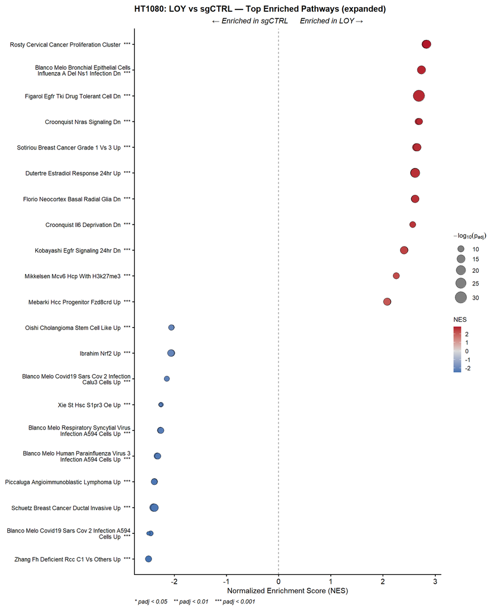

```
## Saved: gsea_dotplot_expanded.(png|pdf)  [6.5x8 in]
```

## 6.5 CGP-only dotplot

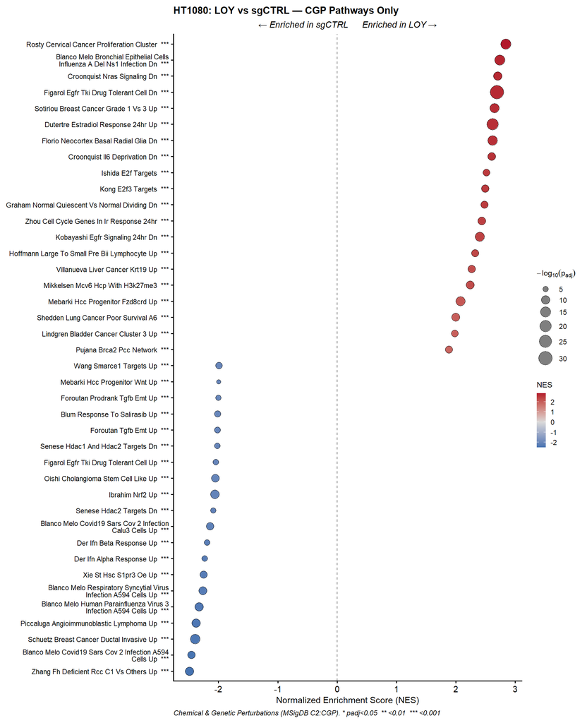

```
## Saved: gsea_dotplot_cgp.(png|pdf)  [6.5x8 in]
```

```
##
## Top 15 CGP pathways (by p-value):
```

LOY vs sgCTRL — Top 15 CGP pathways

| pathway | NES | pval | padj | size |
| --- | --- | --- | --- | --- |
| FIGAROL_EGFR_TKI_DRUG_TOLERANT_CELL_DN | 2.691617 | 0 | 0 | 475 |
| DUTERTRE_ESTRADIOL_RESPONSE_24HR_UP | 2.618599 | 0 | 0 | 295 |
| ROSTY_CERVICAL_CANCER_PROLIFERATION_CLUSTER | 2.841745 | 0 | 0 | 132 |
| BLANCO_MELO_BRONCHIAL_EPITHELIAL_CELLS_INFLUENZA_A_DEL_NS1_INFECTION_DN | 2.738258 | 0 | 0 | 162 |
| SCHUETZ_BREAST_CANCER_DUCTAL_INVASIVE_UP | -2.391113 | 0 | 0 | 270 |
| FLORIO_NEOCORTEX_BASAL_RADIAL_GLIA_DN | 2.617042 | 0 | 0 | 163 |
| KOBAYASHI_EGFR_SIGNALING_24HR_DN | 2.402053 | 0 | 0 | 238 |
| SOTIRIOU_BREAST_CANCER_GRADE_1_VS_3_UP | 2.655111 | 0 | 0 | 142 |
| MEBARKI_HCC_PROGENITOR_FZD8CRD_UP | 2.081439 | 0 | 0 | 479 |
| IBRAHIM_NRF2_UP | -2.059034 | 0 | 0 | 483 |
| ZHANG_FH_DEFICIENT_RCC_C1_VS_OTHERS_UP | -2.490476 | 0 | 0 | 114 |
| CROONQUIST_NRAS_SIGNALING_DN | 2.701642 | 0 | 0 | 67 |
| PICCALUGA_ANGIOIMMUNOBLASTIC_LYMPHOMA_UP | -2.378503 | 0 | 0 | 155 |
| BLANCO_MELO_HUMAN_PARAINFLUENZA_VIRUS_3_INFECTION_A594_CELLS_UP | -2.325458 | 0 | 0 | 169 |
| MIKKELSEN_MCV6_HCP_WITH_H3K27ME3 | 2.244324 | 0 | 0 | 214 |

# 7. Chromatin / PRC2 Deep Dive

Polycomb / bivalent gene sets (MIKKELSEN H3K27me3 / H3K4me3+H3K27me3 bivalent sets, MEISSNER bivalent sets, BENPORATH PRC2 / SUZ12 targets, KAMMINGA EZH2 targets, PASINI SUZ12 targets) all converge on developmental genes that in normal cells carry H3K27me3 and/or bivalent H3K4me3+H3K27me3 promoter marks. Coordinated regulation of these sets points at a chromatin-state shift in LOY rather than scattered single-gene effects. The same query is applied to HT1080 here for direct comparison with the HT1080 result.

## 7.1 Chromatin pathway dotplot

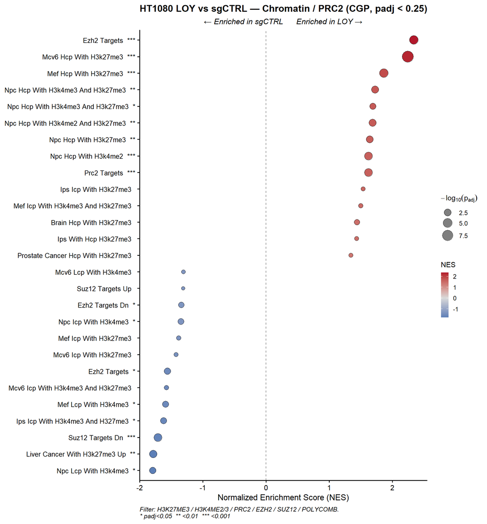

```
## Saved: gsea_dotplot_chromatin.(png|pdf)  [6.5x7 in]
##
## Chromatin pathways at padj < 0.05:
```

HT1080 LOY vs sgCTRL — significant chromatin pathways

| pathway | NES | pval | padj | size |
| --- | --- | --- | --- | --- |
| MIKKELSEN_MCV6_HCP_WITH_H3K27ME3 | 2.244324 | 0.0000000 | 0.0000000 | 214 |
| KAMMINGA_EZH2_TARGETS | 2.338457 | 0.0000010 | 0.0000378 | 38 |
| MIKKELSEN_MEF_HCP_WITH_H3K27ME3 | 1.863403 | 0.0000010 | 0.0000378 | 226 |
| PASINI_SUZ12_TARGETS_DN | -1.710978 | 0.0000072 | 0.0002040 | 278 |
| BENPORATH_PRC2_TARGETS | 1.620251 | 0.0000109 | 0.0002891 | 320 |
| MEISSNER_NPC_HCP_WITH_H3K4ME2 | 1.620729 | 0.0000164 | 0.0004110 | 329 |
| ACEVEDO_LIVER_CANCER_WITH_H3K27ME3_UP | -1.786564 | 0.0000640 | 0.0012078 | 149 |
| MEISSNER_NPC_HCP_WITH_H3K4ME2_AND_H3K27ME3 | 1.686924 | 0.0001039 | 0.0017753 | 170 |
| MIKKELSEN_NPC_HCP_WITH_H3K4ME3_AND_H3K27ME3 | 1.727572 | 0.0001806 | 0.0027915 | 138 |
| MIKKELSEN_NPC_HCP_WITH_H3K27ME3 | 1.639513 | 0.0003839 | 0.0049797 | 148 |
| MIKKELSEN_NPC_LCP_WITH_H3K4ME3 | -1.793791 | 0.0013562 | 0.0128215 | 44 |
| KONDO_EZH2_TARGETS | -1.560814 | 0.0017630 | 0.0155296 | 172 |
| MEISSNER_NPC_HCP_WITH_H3K4ME3_AND_H3K27ME3 | 1.691745 | 0.0018529 | 0.0159943 | 96 |
| MIKKELSEN_MEF_LCP_WITH_H3K4ME3 | -1.588687 | 0.0022272 | 0.0184032 | 93 |
| MIKKELSEN_IPS_ICP_WITH_H3K4ME3_AND_H327ME3 | -1.619866 | 0.0028510 | 0.0223619 | 63 |
| MIKKELSEN_NPC_ICP_WITH_H3K4ME3 | -1.349014 | 0.0056449 | 0.0372619 | 354 |
| LU_EZH2_TARGETS_DN | -1.342027 | 0.0060917 | 0.0392543 | 343 |

## 7.2 Enrichment curves for top chromatin pathways

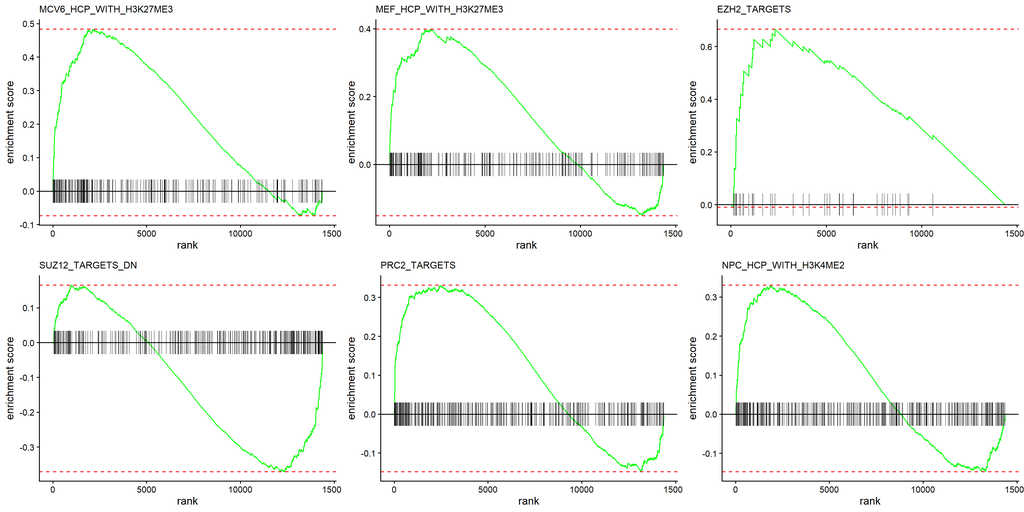

```
## Saved: gsea_enrichment_chromatin.(png|pdf)  [12x6 in]
```

## 7.3 H3K27me3 target gene volcano

Highlight `MIKKELSEN_MEF_HCP_WITH_H3K27ME3` member genes (bivalent-promoter developmental regulators carrying H3K27me3 in MEFs) on the full DE volcano.

```
## H3K27me3 set genes in DE: 227
##   nom. p < 0.05 & up:   65
##   nom. p < 0.05 & down: 29
```

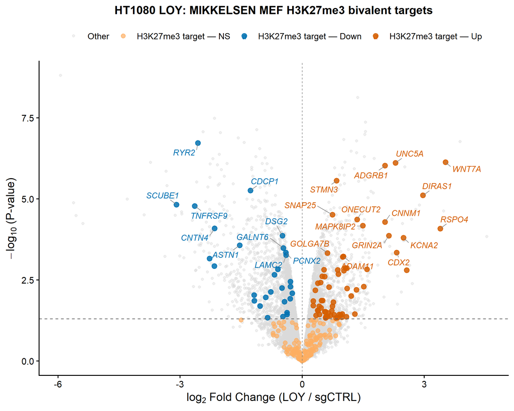

```
## Saved: volcano_h3k27me3_targets.(png|pdf)  [7.5x6 in]
```

# 8. NRAS Signalling & the Cell-Cycle Paradox

**Working hypothesis.** HT1080 carries an activating **NRAS Q61K** mutation (COSMIC CCLE entry). NRAS Q61K is a constitutively active oncoprotein that drives MAPK and PI3K signalling into the cell-cycle machinery regardless of upstream input. In a cell already running RAS at saturation, a further LOY-induced bump in cell-cycle transcription may hit a ceiling downstream — receptor-level / metabolic / DNA-replication bottlenecks cap actual proliferation, while transcription still “writes the order” at E2F / MYC. This section unpacks the transcriptional side of that story.

## 8.1 NRAS / cell-cycle pathway dotplot

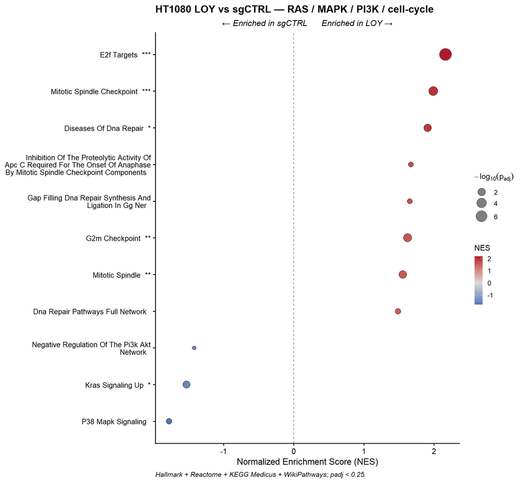

```
## Saved: gsea_dotplot_nras_cellcycle.(png|pdf)  [6.5x6 in]
```

## 8.2 Enrichment curves: RAS/MAPK + cell cycle

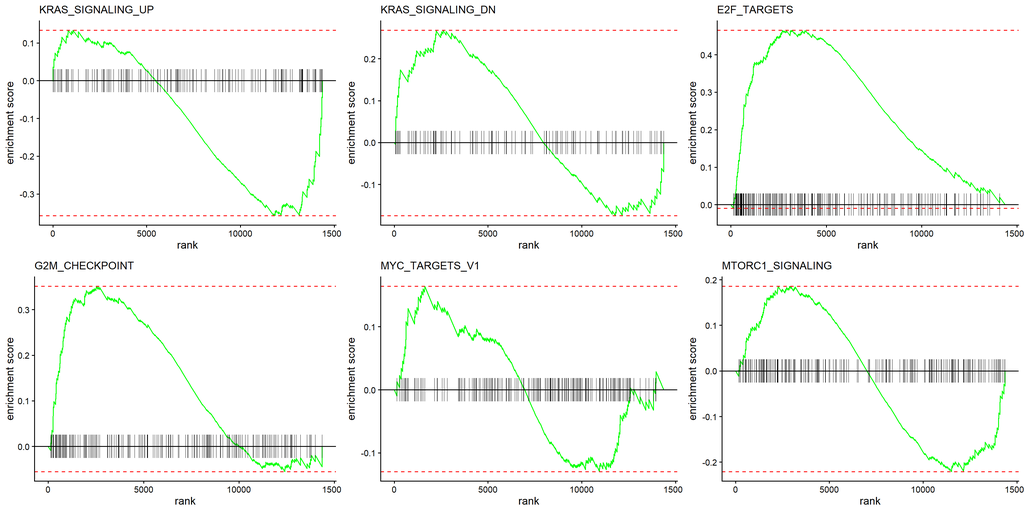

```
## Saved: gsea_enrichment_nras_cellcycle.(png|pdf)  [12x6 in]
```

## 8.3 Cell-cycle gene overlay on volcano

Highlight Hallmark **E2F_TARGETS** member genes on the full DE volcano — shows whether the cell-cycle enrichment comes from many small coordinated shifts (“lots of small nudges, not a few big hits”) or a handful of outliers.

```
## E2F_TARGETS genes in DE: 195
##   nom. p<0.05 & up:   52
##   nom. p<0.05 & down: 9
```

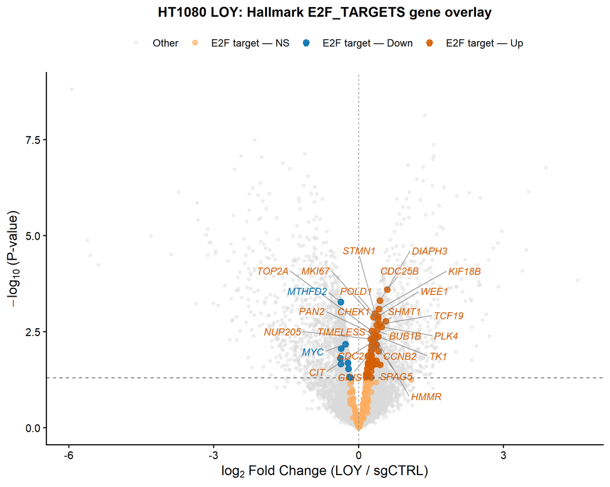

```
## Saved: volcano_e2f_targets.(png|pdf)  [7.5x6 in]
```

## 8.4 Expression of NRAS and key cell-cycle / proliferation genes

Per-sample logCPM for the key players. If cell-cycle transcription is “writing the order” but proliferation doesn’t rise, expect E2F targets up in LOY at the transcript level, but proliferation markers (MKI67) and the cyclins that bottleneck progression (CCND1, CCNE1) to **not** change appreciably.

```
## Focus genes present in DGE: 14
```

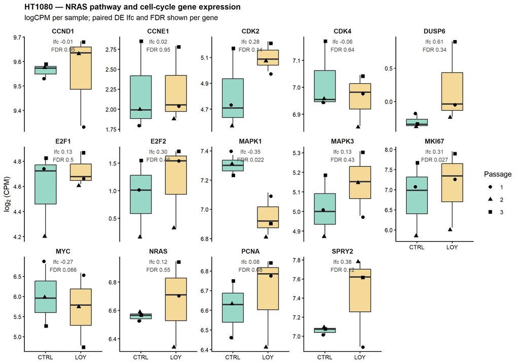

```
## Saved: nras_cellcycle_boxplots.(png|pdf)  [10x7 in]
```

**Read this plot as:** Does NRAS itself move? (Likely not — it’s the activating Q61K mutation that matters, not transcript level.) Do downstream E2F / MYC / cyclin transcripts move up in LOY? (Expected yes — this is the “paradox” signal.) Do the ultimate proliferation markers (MKI67, PCNA) move? (If they stay flat, that’s the downstream bottleneck — the cells *transcribe* a faster program but don’t *run* it faster.)

# 9. TF Regulon Activity (DoRothEA + decoupleR)

Two orthogonal methods to infer which transcription factors drive the LOY-vs-sgCTRL transcriptional program:

1. **DoRothEA + fgsea** — regulon-enrichment of MoR-weighted t-stats.
2. **decoupleR ULM (CollecTRI network)** — univariate linear model applied sample-by-sample (heatmap) and on the contrast t-stats (bar/volcano/scatter).

Both methods use the paired-design DE (`de_loy_ctrl`) and the ribo-filtered t-stat ranks (`ranks_loy_ctrl`).

## 9.1 Load DoRothEA regulons

```
## Loaded 246 TF regulons (A/B/C)
```

```
## Regulon size range: 10 - 383 (median: 32)
```

## 9.2 Run fgsea on MoR-weighted ranks

```
## Significant TFs (padj < 0.05): 12
```

## 9.3 Top TF results

```
##
## === Top 15 Activated TFs ===
```

| pathway | NES | padj | size |
| --- | --- | --- | --- |
| E2F4 | 1.655 | 0.006 | 220 |
| ZEB2 | 2.105 | 0.008 | 17 |
| PRDM14 | 1.541 | 0.030 | 164 |

```
##
## === Top 15 Repressed TFs ===
```

| pathway | NES | padj | size |
| --- | --- | --- | --- |
| SOX2 | -1.908 | 0.000 | 229 |
| STAT1 | -1.698 | 0.005 | 236 |
| GRHL2 | -1.917 | 0.008 | 48 |
| ETS1 | -1.789 | 0.009 | 108 |
| SOX6 | -1.933 | 0.009 | 13 |
| ZNF263 | -1.583 | 0.009 | 275 |
| SMAD3 | -1.995 | 0.013 | 25 |
| SRF | -1.868 | 0.019 | 9 |
| MAZ | -1.825 | 0.041 | 38 |

## 9.4 TF activity volcano

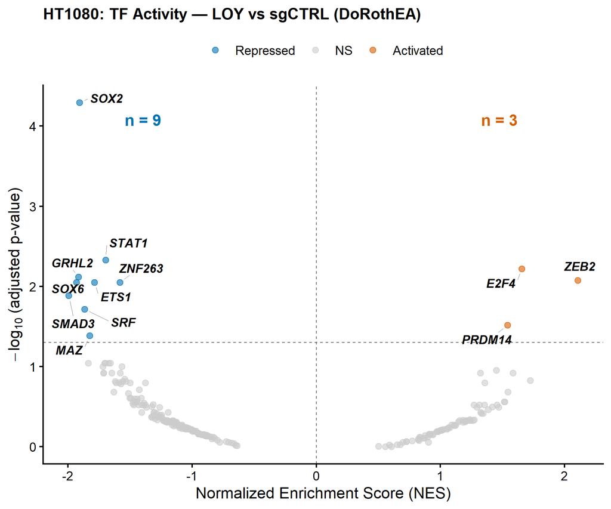

```
## Saved: tf_volcano_LOY_v_sgCTRL.(png|pdf)  [6x5 in]
```

## 9.5 TF activity dotplot

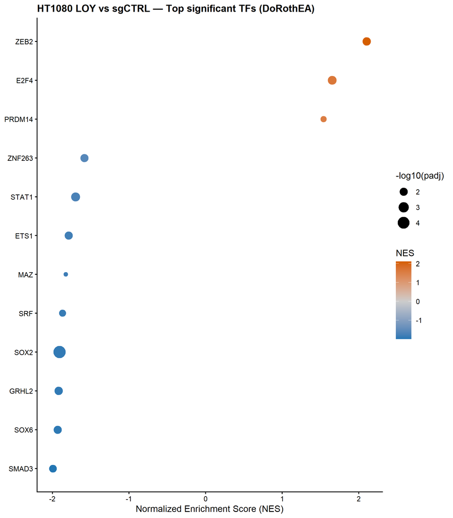

```
## Saved: tf_dotplot_LOY_v_sgCTRL.(png|pdf)  [7x8 in]
```

## 9.6 TF enrichment curves (top 3 activated + top 3 repressed)

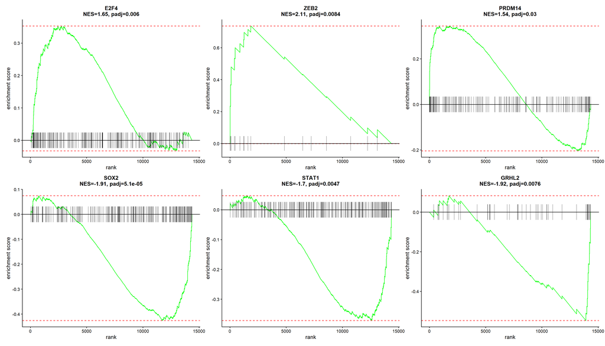

```
## Saved: tf_enrichment_top_LOY_v_sgCTRL.(png|pdf)  [14x8 in]
```

## 9.7 TF regulon overlay on DE volcano (top 6)

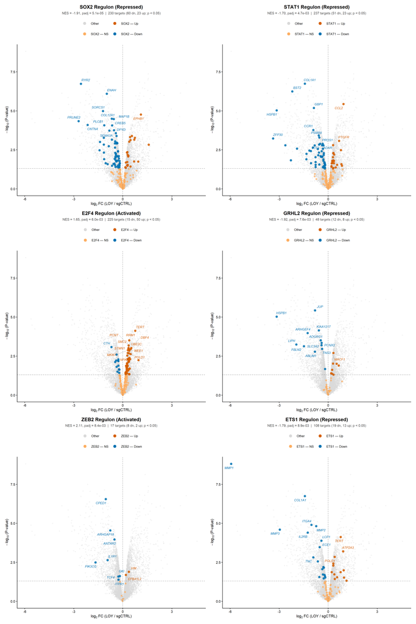

```
## Saved: tf_regulon_targets_LOY_v_sgCTRL.(png|pdf)  [12x18 in]
```

## 9.8 decoupleR — CollecTRI network

```
## CollecTRI network: 43159 interactions, 1186 TFs, 6686 targets
```

## 9.9 Sample-level TF activity (ULM)

```
## Sample-level ULM: 660 TFs × 6 samples
```

## 9.10 Sample-level TF activity heatmap (top variable)

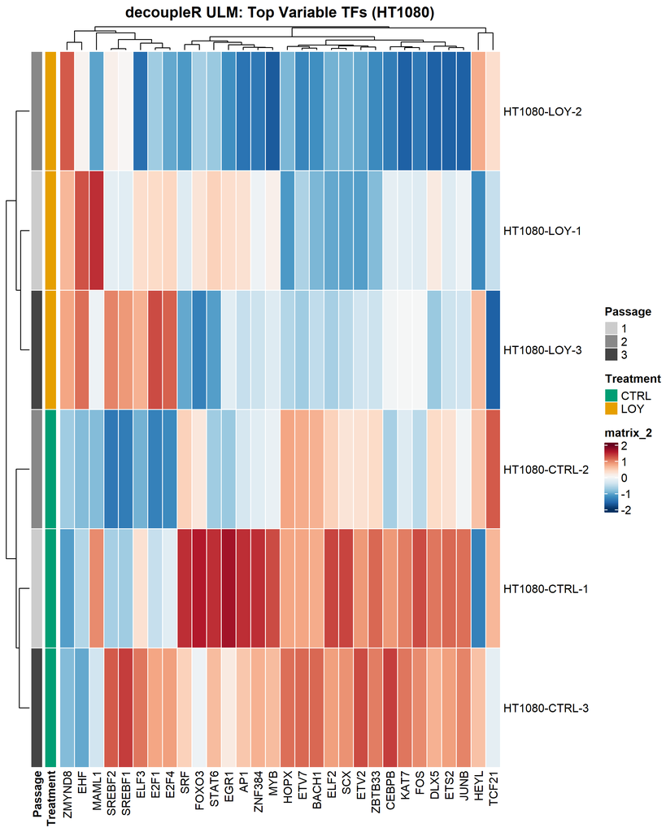

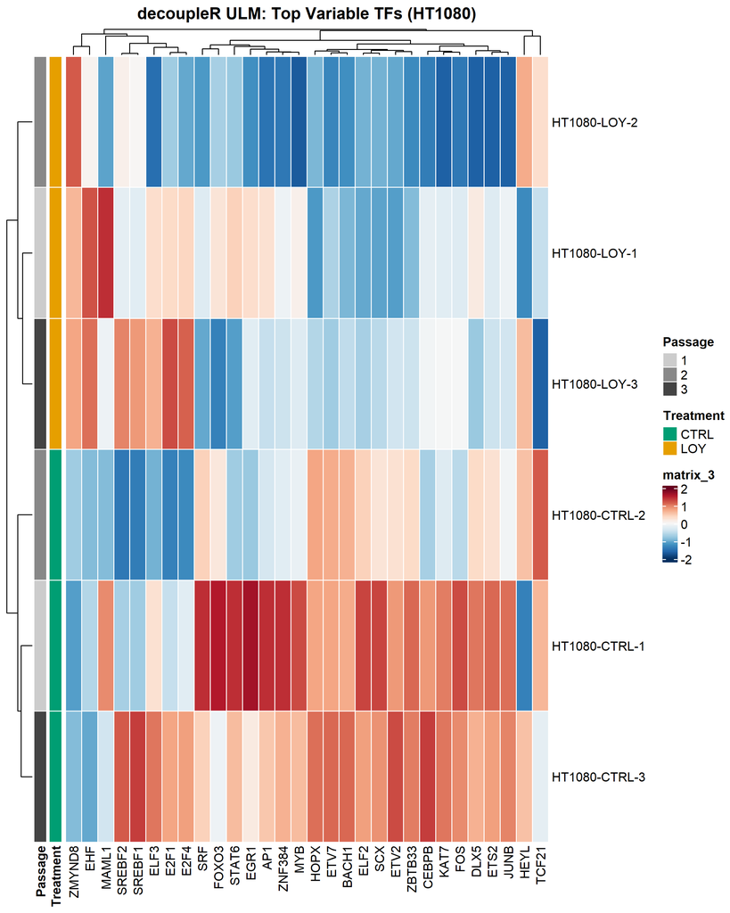

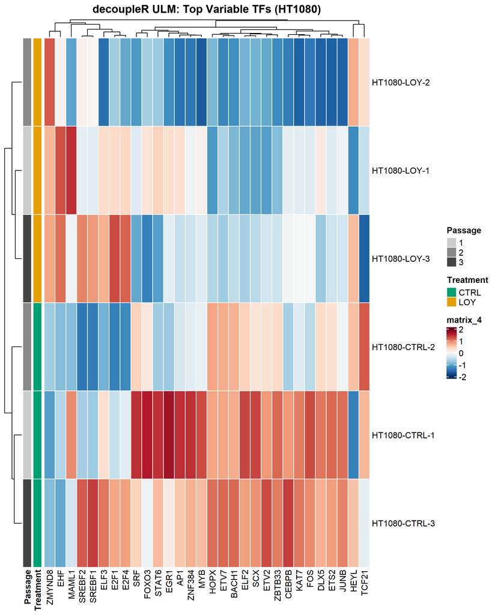

```
## Saved: decouple_TF_heatmap_LOY_v_sgCTRL.(png|pdf) [8x10 in]
```

## 9.11 Contrast-level TF activity (ULM on paired t-stats)

```
## Contrast-level ULM: 660 TFs scored
```

## 9.12 TF activity bar plot

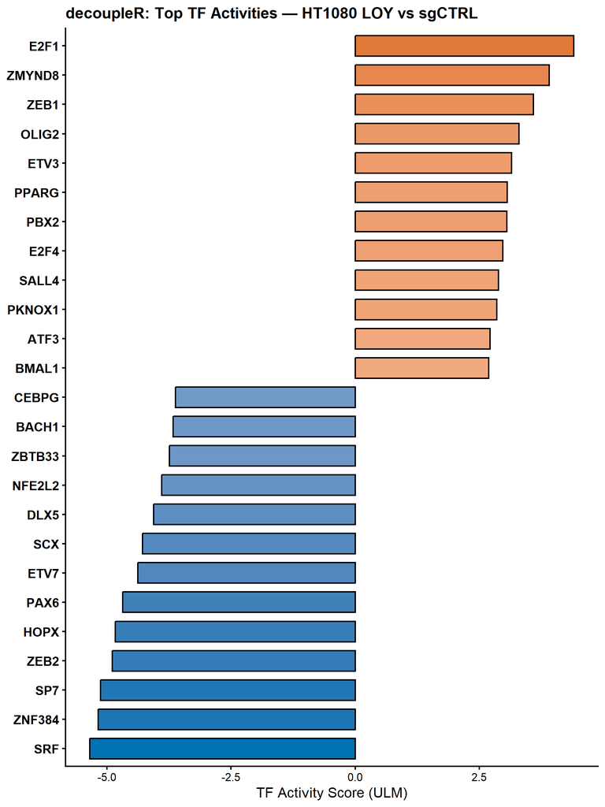

```
## Saved: decouple_TF_barplot_LOY_v_sgCTRL.(png|pdf)  [6x8 in]
```

## 9.13 Contrast-level TF volcano (decoupleR)

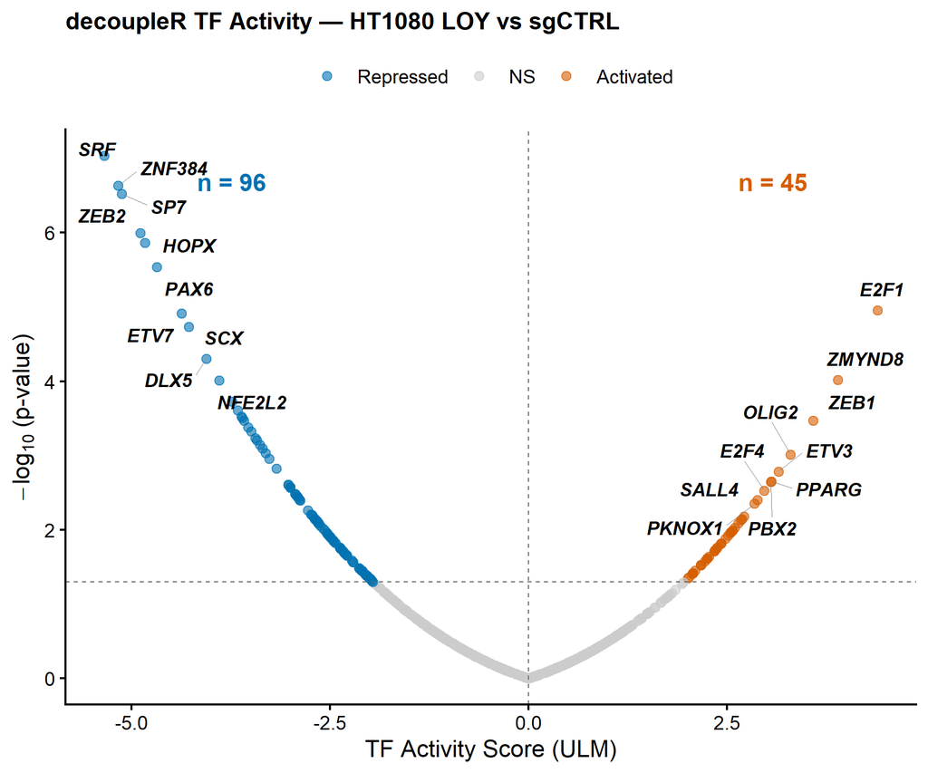

```
## Saved: decouple_TF_volcano_LOY_v_sgCTRL.(png|pdf)  [6x5 in]
```

## 9.14 Target gene scatter for top TFs (decoupleR)

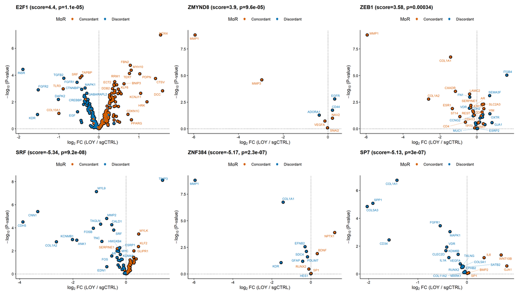

```
## Saved: decouple_TF_target_scatter_LOY_v_sgCTRL.(png|pdf)  [14x8 in]
```

## 9.15 Save decoupleR results

```
## decoupleR results saved to: A:/Dropbox/LOY_paralogs/projects/github/loy-synthetic-lethality/analysis/02_rnaseq/HT1080/TF_analysis
```

**Interpretation.** The DoRothEA fgsea and decoupleR ULM analyses both infer TF activity from the coordinated regulation of each TF’s downstream targets — not from the TF’s own mRNA level. Agreement between the two methods on a TF (e.g., same direction in both volcanos) is the strongest evidence that the TF’s activity is altered in LOY. Differences can reflect (i) method weighting, (ii) regulon source (DoRothEA pancancer vs CollecTRI), or (iii) which targets were measured in this dataset.

# 10. Top-DEG Expression Boxplots

Per-sample logCPM for the strongest individual differentially-expressed genes (paired DE, Y-chr removed) — the individual-gene complement to the GSEA pathway view.

```
## Top up   (FDR<0.05 & lfc>0.75):  20 genes
```

```
## Top down (FDR<0.05 & lfc<-0.75): 20 genes
```

## Top 20 Up in LOY

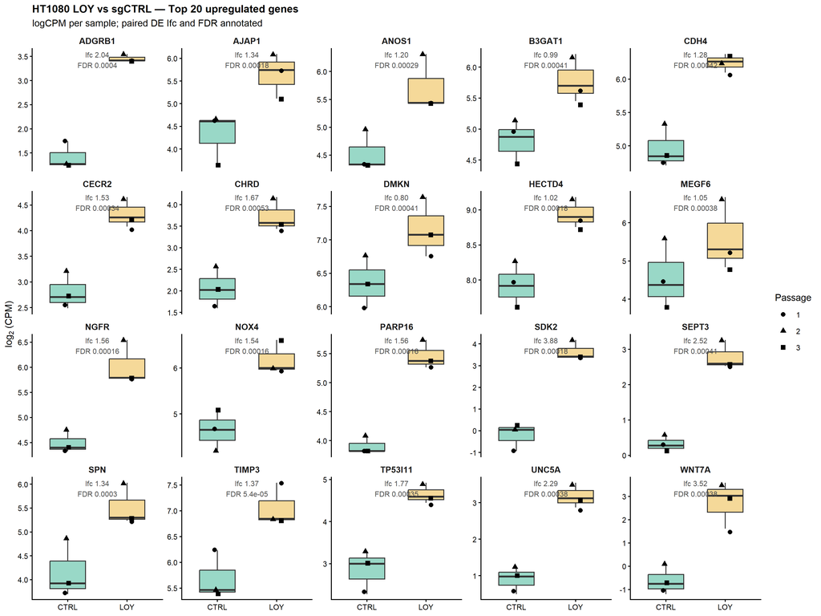

```
## Saved: boxplots_top20_up.(png|pdf)  [12x9 in]
```

## Top 20 Down in LOY

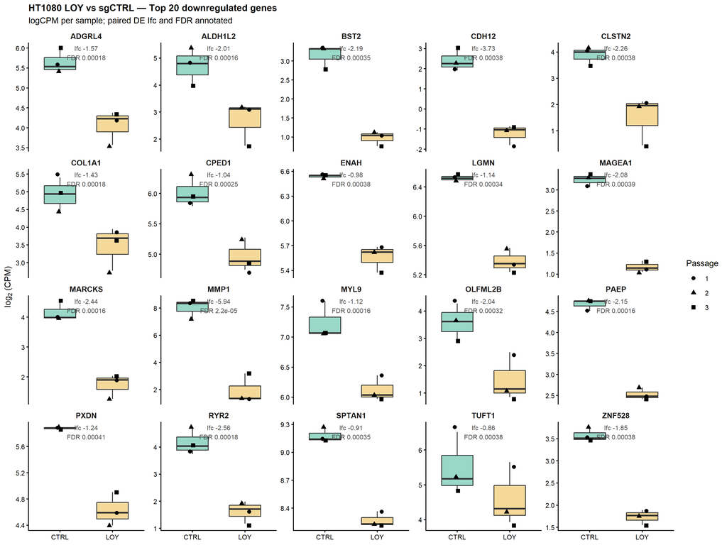

```
## Saved: boxplots_top20_down.(png|pdf)  [12x9 in]
```